# main-Copy1

```python
from IPython.display import display
from IPython.display import HTML
import IPython.core.display as di

di.display_html('<script>jQuery(function() {if (jQuery("body.notebook_app").length == 0) { jQuery(".input_area").toggle(); jQuery(".prompt").toggle();}});</script>', raw=True)
```

```python
import numpy as np
import pandas as pd
import matplotlib as mpl
import matplotlib.pyplot as plt
import seaborn as sns
import plotly
import plotly.express as px
import plotly.graph_objects as go
import cufflinks as cf
import plotly.offline as pyo
from plotly.offline import init_notebook_mode,plot,iplot
import folium
from folium import plugins
from SEIRclass import *
mpl.style.use('seaborn')
plt.style.use('seaborn')
import warnings
warnings.filterwarnings("ignore")
pyo.init_notebook_mode(connected=True)
cf.go_offline()
```

```python
df = pd.read_csv('./case_time_series.csv')
df.head();
```

```python
pop = df[['Date', 'Daily Confirmed', 'Total Confirmed', 'Daily Deceased', 'Total Deceased']][62:]
```

```python
pop['CFR'] = (pop['Daily Deceased']/pop['Daily Confirmed'])*100
pop.head();
```

```python
df[453:]['Total Deceased']/df[453:]['Total Confirmed']*100
pop['CFR'][pop['CFR']>17.5]
pop['CFR'][pop['CFR']>17.5] = (df[453:]['Total Deceased']/df[453:]['Total Confirmed']*100).apply(lambda x: float(x))
```

```python
df1 = pop[0:183]
df1 =  df1.reset_index()
df1.head();
```

```python
df2 = pop[183:334]
df2 = df2.reset_index()
df2.head();
```

```python
df3 = pop[334:]
df3 = df3.reset_index()
df3.head();
```

# Analysis and Simulation of COVID-19

India is facing a severe second wave of COVID-19 which is much worse than the first wave. It is spreading much faster. India has now surpassed U.S. in terms of daily COVID-19 cases. This paper aims to analyse the trend of COVID-19 and examine why second wave happened and why it is so bad by simulating a simple SEIR model. Which is a compartmental model based on 4 compartments Susceptible, Exposed, Infectious, Recovered.

```python
dfs= pd.read_csv("./state_wise.csv")
dfs.head();
```

```python
dfs.drop(['ConfirmedIndianNational','ConfirmedForeignNational'],axis=1,inplace=True)
dfs.head();
```

```python
state_cases = dfs.groupby('State/UnionTerritory')['Confirmed','Deaths','Cured'].max().reset_index()
state_cases['Active'] = state_cases['Confirmed'] - (state_cases['Deaths']+ state_cases['Cured'])
state_cases["Death Rate (per 100)"] = np.round(100*state_cases["Deaths"]/state_cases["Confirmed"],2)
state_cases["Cure Rate (per 100)"] = np.round(100*state_cases["Cured"]/state_cases["Confirmed"],2)
state_cases.head();
```

```python
px.treemap(state_cases,path=["State/UnionTerritory"],values="Confirmed",title="Overall States confirmed cases Comparision till 3rd may 2021")
```

[interactive chart not shown]

#### Covid cases trend

```
<BarContainer object of 63 artists>
```

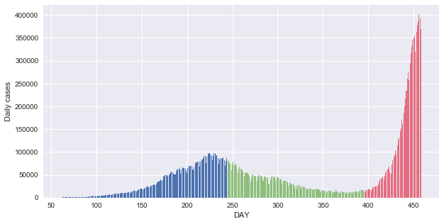

```python
mpl.style.use('seaborn')
plt.figure(figsize=(10,5))
plt.xlabel('DAY')
plt.ylabel('Daily cases')
plt.bar(df1['index'], df1['Daily Confirmed'], label='Dawn (Phase 1)')
plt.bar(df2['index'], df2['Daily Confirmed'], color = '#8ebf7a', label='Calm (Phase 2)')
plt.bar(df3['index'], df3['Daily Confirmed'], color = '#e66c80', label='Storm (Phase 3)')
```

#### Fatality Ratio

```python
dfs['Fatality-Ratio'] = dfs['Deaths']/dfs['Confirmed']
```

```python
fatality_year=dfs.groupby('Date')['Fatality-Ratio'].sum().reset_index()
fatality_year.iplot(kind='line',x='Date',y='Fatality-Ratio')
```

[interactive chart not shown]

### SEIR Model

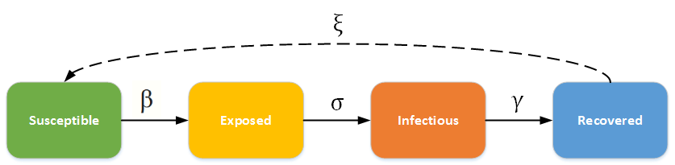

𝑑𝑆/𝑑𝑡=−𝜌.𝛽.𝑆.𝐼

𝑑𝐸/𝑑𝑡=𝜌.𝛽.𝑆.𝐼−𝛼.𝐸

𝑑𝐼/𝑑𝑡=𝛼.𝐸−𝛾.𝐼

𝑑𝑅/𝑑𝑡=𝛾.𝐼

were,

𝛼 is the inverse of the virus incubation period

𝛽 is the average contact rate in the population

𝛾 is the inverse of the mean infectious period

𝜌 is the social mixing factor

```python
s = SEIR()
```

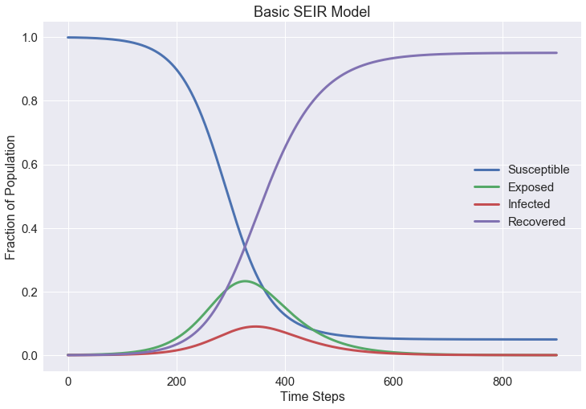

```python
r=s.run(t_max=90,dt=0.1)
s.plot(r)
```

This is the normal trend of the covid-19, number of susceptible people decreases as number of recovered people increases and the infected people first increases and then decreases.

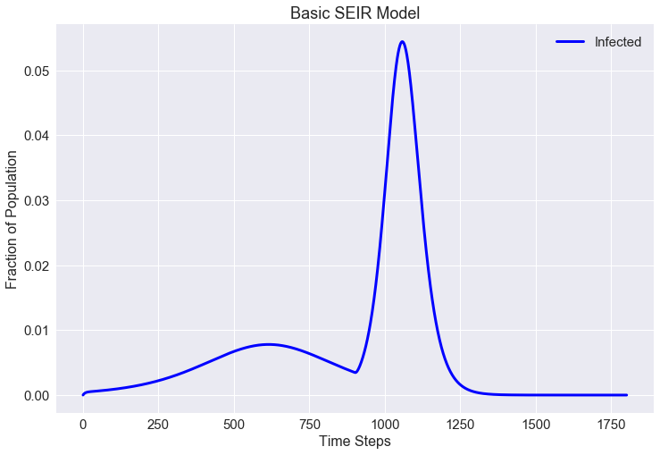

```python
p = [0.7,2.1,0.7,0.1]
s1 = SEIR(params_=p)
s1.rho=0.4
r1=s1.run(t_max=90,dt=0.1)
new_init = s1.vals_
s2 = SEIR(init_vals=new_init,params_=p)
s2.rho = 0.9
r2=s2.run(t_max=90,dt=0.1,reset=False)
r3=np.vstack((r1,r2))
s2.plot_var(r3[:,2],var_name='Infected')
```

This is the trend when lockdown is lifted and people stopped social distancing. Second wave is much higher than the first one as what we are seeing now in India.

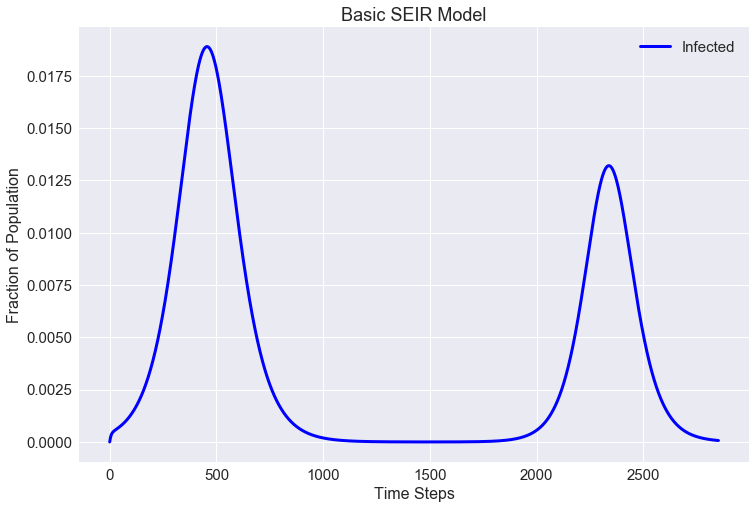

```python
s1 = SEIR(params_=p)
s1.rho=0.45
r1=s1.run(t_max=150,dt=0.1)
new_init = s1.vals_
s2 = SEIR(init_vals=new_init,
          params_=p)
s2.rho = 0.9
r2=s2.run(t_max=135,dt=0.1,reset=False)
r3=np.vstack((r1,r2))
s2.plot_var(r3[:,2],var_name='Infected')
```

This is the trend of infected people when lockdown is long enough to build some herd immunity and people takes some precautions.

#### Conclusion

Second wave is severe because lockdown was lifted and people stopped social distancing. Also, the mutation made the virus more infectious. Although the cases are high but the fatality ratio is less compared to earlier. We need to take precautions get the most of population vaccinated in order to fight this virus.